# Supervised Bayesian Matrix Factorization

Joint Gene Expression Programs & Survival Modeling in PDAC

Andrew Walther

Department of Biostatistics, UNC Gillings School of Global Public Health

2026-04-09

## Outline

**Motivation** · The PDAC challenge & why supervised factorisation matters

**Methods** · SBMF model · Dual-source objective · EBNM adaptive priors · CAVI inference

**Results** · Synthetic validation · Seven PDAC cohorts · Prior × K comparison · Deep dives

**Future Directions & Summary**

## The PDAC Problem

### Pancreatic Ductal Adenocarcinoma

- **Five-year survival < 12%** — one of the most lethal solid tumors
- Most patients diagnosed at advanced stage with limited treatment options
- **No widely adopted molecular stratification** at diagnosis
- Tumors are a complex mixture of malignant, stromal, and immune cells — gene expression signals are deeply interwoven
- **Goal:** identify *gene expression programs* (GEPs) whose activation levels predict patient survival

**The Clinical Need**

Reliable prognostic signatures could:

- Stratify patients for targeted therapy
- Define subgroups for clinical trial enrollment
- Distinguish molecular features that *describe* tumor heterogeneity from those that *predict* disease course

## Why Supervised > Unsupervised

### The PCA-Then-Test Gap

**Standard approach:**

1. Apply PCA or NMF to expression data
2. Find axes of greatest expression variance
3. Test for survival association *post hoc*

**The problem:**

- Expression-dominant axes may reflect batch effects or housekeeping genes
- Programs with **modest expression variance** but **strong survival signal** get missed
- Post-hoc testing is statistically conservative

**Supervised approach:**

1. Integrate survival into the factorisation objective *directly*
2. Factors are simultaneously constrained to explain expression **and** predict survival
3. If $\hat{\beta}_k = 0$, factor $k$ explains expression only — the model naturally separates prognostic from non-prognostic structure

**Key Insight**

A factor explaining 15% of variance might be entirely batch effects. A factor explaining 3% might perfectly separate survivors from non-survivors. PCA prioritises the first and ignores the second.

## The Gap & Our Approach

### What Existing Supervised MF Approaches Are Missing

- **Data-adaptive shrinkage priors** — existing methods use fixed penalties; we let the prior learn from the data
- **Automatic K selection** — no need to grid-search the number of factors
- **Uncertainty quantification** — posterior inference gives us credible intervals, not just point estimates

**SBMF vs. Penalised Supervised Approaches**

Penalised approaches (e.g., deSurv from our lab) optimise a weighted objective $(1-\alpha)\mathcal{L}_\text{NMF} + \alpha\mathcal{L}_\text{Cox}$, requiring a tuning parameter $\alpha$ to balance the two terms. **SBMF** instead uses full Bayesian inference:

- The **ELBO** naturally balances genomics and survival — no $\alpha$ needed
- **EBNM** priors adapt their shrinkage to the data
- Posterior second moments ($E[L^2] \neq \bar{L}^2$) prevent overfitting to uncertain loadings

> **SBMF:** Learn gene expression programs and survival associations simultaneously, with the prior learning from the data.

## The SBMF Model

### Joint Genomics + Survival Factorisation

$$Y = LF^\top + E, \quad E_{ij} \sim N(0, \tau_j^{-1})$$

$$h_i(t) = h_0(t)\exp(L_i \cdot \beta)$$

**Baseline Hazard**

$h_0(t)$ is **non-parametric** — it cancels exactly in the Cox partial likelihood. No shape assumption (Weibull, exponential) is made; the model only requires the proportional hazards structure.

| Quantity | Dimension | Meaning |
| --- | --- | --- |
| $Y$ | $n \times p$ | Gene expression matrix |
| $L$ | $n \times K$ | Patient activation scores |
| $F$ | $p \times K$ | Gene weights per program |
| $\beta$ | $K \times 1$ | Survival coefficients |
| $\tau_j$ | scalar | Gene-specific precision |
| $q(L_k), q(F_k), q(\beta_k)$ | — | EBNM prior (point-normal or point-laplace); hyperparameters estimated via empirical Bayes |

**The Shared Latent Space**

The **same** $L$ drives both:

- Low-rank reconstruction of gene expression ($LF^\top$)
- Cox proportional hazards risk score ($L\beta$)

This forces factors to explain expression variance **and** maximise survival signal simultaneously.

## Dual-Source Objective Function

### How the Joint Objective Is Constructed

**Genomics Likelihood**

$$\mathcal{L}_\text{genomics} = \sum_{j=1}^{p} \log p(Y_{\cdot j} \mid L, F_j, \tau_j)$$

Gaussian reconstruction error — how well $LF^\top$ approximates $Y$

**Survival Likelihood**

$$\mathcal{L}_\text{Cox} = \sum_{i:\delta_i=1} \left[ L_i\beta - \log \sum_{j \in \mathcal{R}_i} \exp(L_j\beta) \right]$$

Cox partial log-likelihood — how well $L\beta$ predicts survival

### Combined ELBO

$$\text{ELBO} = \underbrace{E_q[\mathcal{L}_\text{genomics}]}_{\text{expression fit}} + \underbrace{E_q[\mathcal{L}_\text{Cox}]}_{\text{survival fit}} - \underbrace{D_\text{KL}(q \| \pi)}_{\text{prior regularisation}}$$

The ELBO **naturally balances** both objectives — no tuning parameter $\alpha$ required. The shared $L$ appears in both terms.

**Gradient Scale Asymmetry**

The genomics term sums over $p$ features; the Cox term over $n$ patients. Since $p \gg n$ in genomics data, the genomics gradient dominates — the relative magnitudes are **not normalised** and may be dataset-dependent. Adding a scalar $\lambda$ to weight $E_q[\mathcal{L}_\text{Cox}]$ is an active research direction (see roadmap).

## EBNM & Adaptive Shrinkage

### From Penalised Regression to Empirical Bayes

**What you already know:**

- **Ridge/LASSO** shrink coefficients toward zero with a *fixed* penalty $\lambda$
- $\lambda$ controls how aggressively we regularise
- Chosen by cross-validation — one $\lambda$ for all coefficients

**The empirical Bayes step:**

- What if the prior *learned from the data* how much to shrink?
- **EBNM** (Empirical Bayes Normal Means): given noisy observations $x_j = \theta_j + \epsilon_j$, estimate the prior $g(\cdot)$ from the data, then compute posterior $E[\theta_j \mid x_j, \hat{g}]$
- The shrinkage adapts *per factor* and *per gene*

**Two prior families tested:**

- **Point-normal:** spike at zero + Gaussian slab; $g(\theta) = \pi_0 \delta_0 + (1-\pi_0)\,N(0, \sigma^2)$
- **Point-laplace:** spike at zero + Laplace slab; heavier tails, better preserves large non-zero effects

**“The Prior Learns From the Data”**

Instead of choosing a penalty strength $\lambda$ by cross-validation, EBNM estimates the mixing proportion (how sparse?) and the scale (how large are the non-zero effects?) directly from the observed data. Implemented via the `ebnm` R package (Stephens lab, U. Chicago).

**Hyperparameter Specification**

- $\pi_0$ (sparsity) and $\sigma^2$ (slab scale) are estimated by marginal likelihood maximisation at each CAVI step — no user-specified tuning
- $\tau_j$ (gene-specific precision): Gamma prior $\tau_j \sim \text{Gamma}(a_0, b_0)$ with weak defaults ($a_0 = b_0 = 10^{-3}$); posterior is closed-form Gamma
- All priors are updated within the ELBO optimisation — the prior adapts to the data at every iteration

## Inference: Factor-Wise CAVI

### Coordinate Ascent Variational Inference

**Mean-field variational family:**
$$q(L, F, \beta, \tau) = \prod_{k=1}^K q(L_{\cdot k})\;\prod_{k=1}^K q(F_{\cdot k})\cdot q(\beta)\cdot q(\tau)$$
Each factor is approximated independently — no posterior correlations across components.

**Gauss-Seidel update order** (per iteration):

For each factor $k = 1, \ldots, K$:

1. **Update $q(L_k)$** — patient loadings via EBNM
   - Precision: $A_{L,i} = \sum_j \tau_j E[F_{jk}^2] + W_{ii} E[\beta_k^2]$
   - Pseudo-data: $x_i = B_{L,i} / A_{L,i}$, scale: $s_i = 1/\sqrt{A_{L,i}}$
2. **Update $q(F_k)$** — gene weights via EBNM (pure genomics)
3. **Update $q(\beta_k)$** — survival coefficient via EBNM (scalar)
4. Deflate residual $R_k$ before proceeding to $k+1$

**Convergence criteria:**

Converged $\iff$ both conditions hold (after $> 5$ burn-in iterations):
$$\text{mean}_{i,k}|L_{ik}^{(t)} - L_{ik}^{(t-1)}| < 10^{-3} \quad \textbf{AND} \quad \text{mean}_k|\beta_k^{(t)} - \beta_k^{(t-1)}| < 10^{-3}$$
- Mean over **all** $n \times K$ loading entries (not max) — prevents oscillating orientation boundaries from blocking convergence - Dual criterion: both genomic structure ($L$) and survival signal ($\beta$) must stabilise

**Automatic K selection:**

- Initialise $K_\text{max} = 10$
- Retain factors with either:
  - PVE $> 1\%$ (non-trivial expression contribution), or
  - $|\hat{\beta}| > 0.05$ (non-negligible survival signal)
- Active factors define $K_\text{eff}$; this is a pragmatic screening rule before future CV-based K selection

## Data Intro — PDAC Cohorts

### Independent Validation Across Three Platforms

| Dataset | Description | Platform | n | Events | Censoring % |
| --- | --- | --- | --- | --- | --- |
| TCGA_PAAD | The Cancer Genome Atlas — Pancreatic Adenocarcinoma | RNA-seq | 144 | 75 | 47.9 |
| CPTAC | Clinical Proteomic Tumor Analysis Consortium | Proteomics | 129 | 64 | 50.4 |
| Dijk | Dijk et al. (Dutch PDAC cohort) | RNA-seq | 90 | 81 | 10.0 |
| Moffitt_GEO_array | Moffitt Cancer Center (Gene Expression Omnibus) | Microarray | 123 | 83 | 32.5 |
| PACA_AU_array | Pancreatic Cancer Australia (ICGC-APGI), array | Microarray | 63 | 38 | 39.7 |
| PACA_AU_seq | Pancreatic Cancer Australia (ICGC-APGI), RNA-seq | RNA-seq | 52 | 31 | 40.4 |
| Puleo_array | Puleo et al. 2018 (Gastroenterology), multi-centre | Microarray | 288 | 181 | 37.2 |

- **RNA-seq** — mRNA transcript counts (TCGA, Dijk, PACA_AU_seq)
- **Microarray** — hybridisation arrays (Moffitt, PACA_AU_array, Puleo)
- **Proteomics** — mass spectrometry protein abundance (CPTAC)
- **Why 7 datasets?** Independent validation across platforms; $n = 52$–$288$; top 5,000 most-variable features, column-centred

## Synthetic Validation

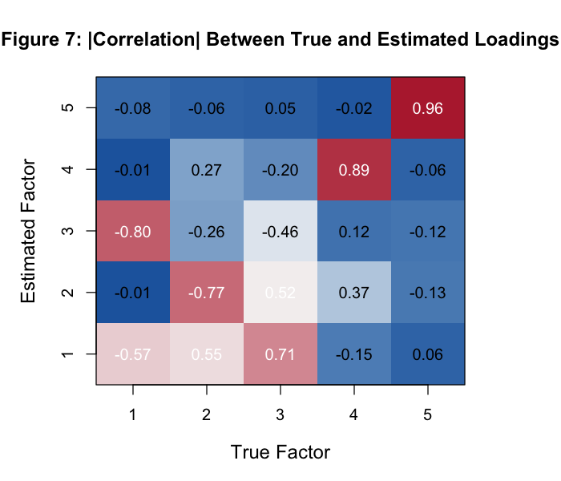

Loading correlations between true and estimated factors

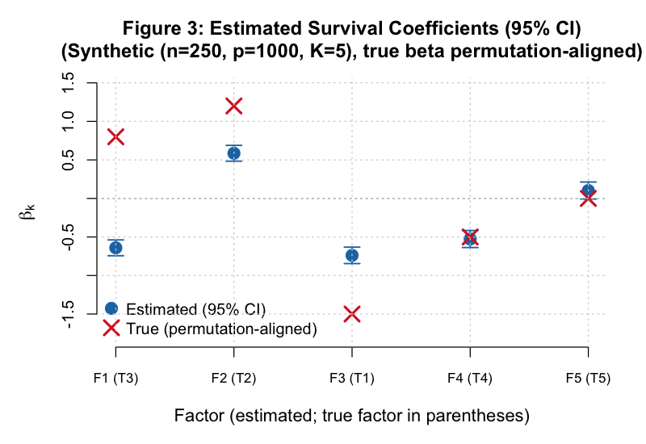

True vs. estimated survival coefficients $\hat{\beta}$

**Proportional Hazards Assumption Verified**

Schoenfeld residual test (`cox.zph`): global $p = 0.335$ — no evidence of PH violation. The same test is reported per-dataset in the PDAC results.

## Convergence & Baseline Performance

### All Seven Cohorts Converge

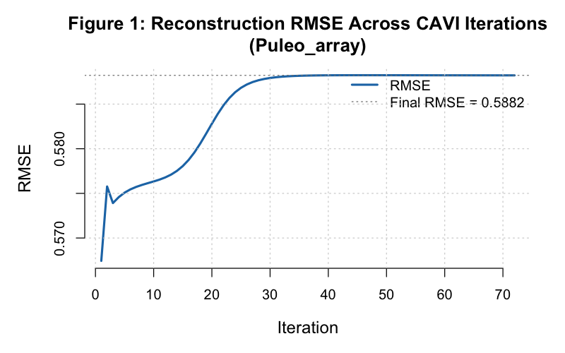

RMSE trace — Puleo array ($n = 288$, converges in 72 iterations)

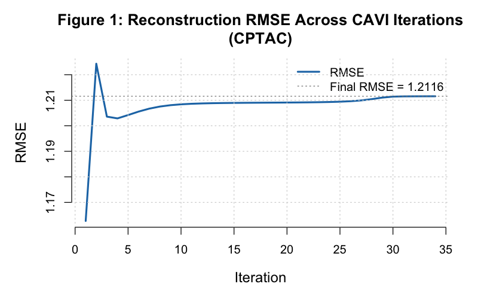

## Prior × K Factorial: The Central Result

### Hold-Out C-index Across Four Conditions

| Dataset | K_eff | PN K=5 | PL K=5 | PN K_eff | PL K_eff |
| --- | --- | --- | --- | --- | --- |
| CPTAC | 8 | 0.389 | 0.605 | 0.635 | 0.623 |
| Dijk | 10 | 0.381 | 0.483 | 0.544* | 0.510 |
| Moffitt | 10 | 0.475 | 0.580* | 0.530 | 0.550 |
| PACA_AU array | 8 | 0.405 | 0.667 | 0.738 | 0.738 |
| PACA_AU seq | 9 | 0.185 | 0.889 | 0.741 | 0.778 |
| Puleo | 10 | 0.396 | 0.594 | 0.674 | 0.649 |
| TCGA | 9 | 0.341 | 0.707* | 0.625* | 0.620* |

- = hit 300-iteration limit. PN = point-normal, PL = point-laplace. 80/20 stratified hold-out.

**Hold-out C-index** — concordance between predicted risk scores and observed survival on 20% held-out patients (random chance = 0.50; higher is better)

**PN K=5** frequently falls below 0.50 (degenerate solutions); **PL K=5** reliably improves over point-normal

Moving to **K_eff** raises mean hold-out C-index from 0.507 to 0.640 overall; **PN K_eff** improves on **PN K=5** in all 7 cohorts

## Prior × K: Scatter Plot

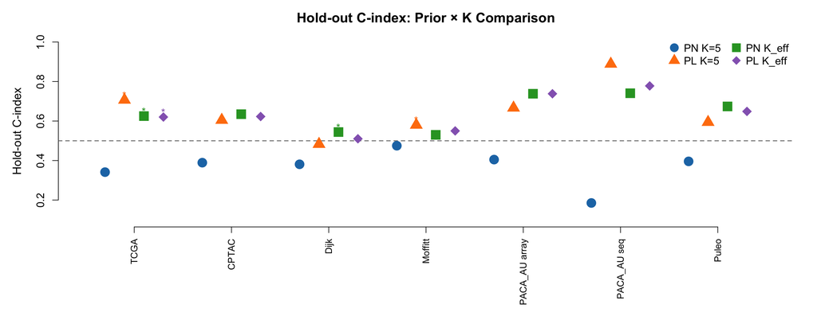

- Each point = one dataset × one condition; dashed line = random chance (C = 0.50); four colours = the four prior × K conditions
- **Blue circles (PN K=5):** several datasets fall well below chance — degenerate fits where $\hat{\beta} \to 0$
- **Moving right (PL → K_eff):** most datasets improve once K is data-adapted, with the biggest rescue coming from PN K=5 to PN K_eff

## Key Findings: Prior × K Comparison

**Point-laplace preferred at fixed K**

**K selection dominates prior choice**

- $K_\text{eff} \in \{8, 9, 10\}$ — **always above** $K = 5$; **PN K_eff** beats **PN K=5** in 7/7 cohorts, while **PL K_eff** beats **PL K=5** in 4/7
- Mean hold-out C-index increases from **0.507** at fixed $K = 5$ to **0.640** under K-adapted fits
- At $K_\text{eff}$: prior advantage is **mixed** (PN wins 4/7)
- Three cohorts saturate at $K_\text{max} = 10$

> **Takeaway:** invest in K selection, not prior tuning.

**Connecting Back to the Three Design Claims**

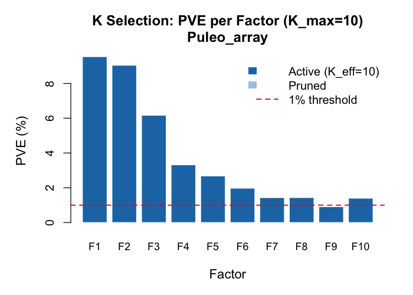

PVE scree — Puleo ($K_\text{eff} = 10$)

## Deep Dive: Puleo Array ($n = 288$)

### The Clearest Factor Structure

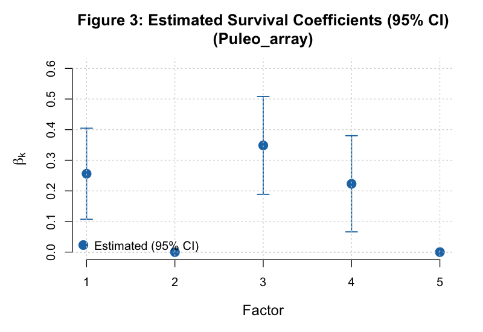

Survival coefficients $\hat{\beta}$ per GEP

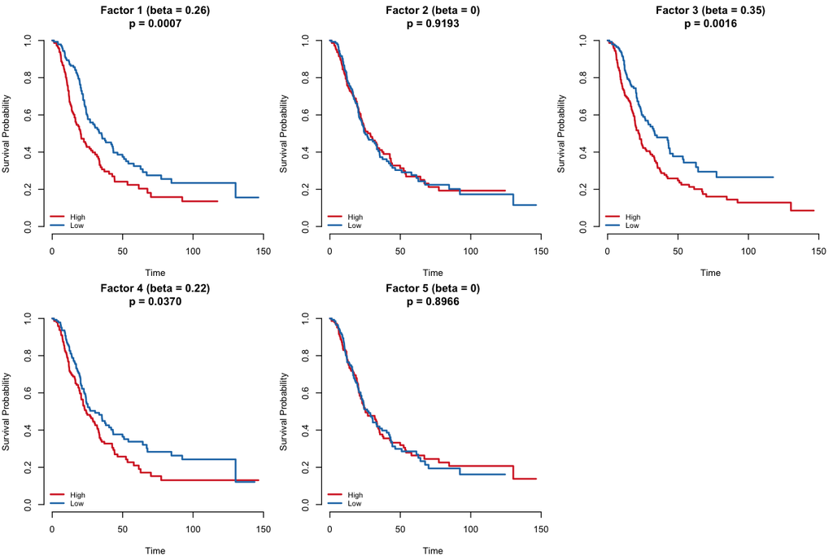

Kaplan-Meier survival curves by GEP activation

## Deep Dive: TCGA_PAAD

### The Most Widely Studied PDAC Cohort

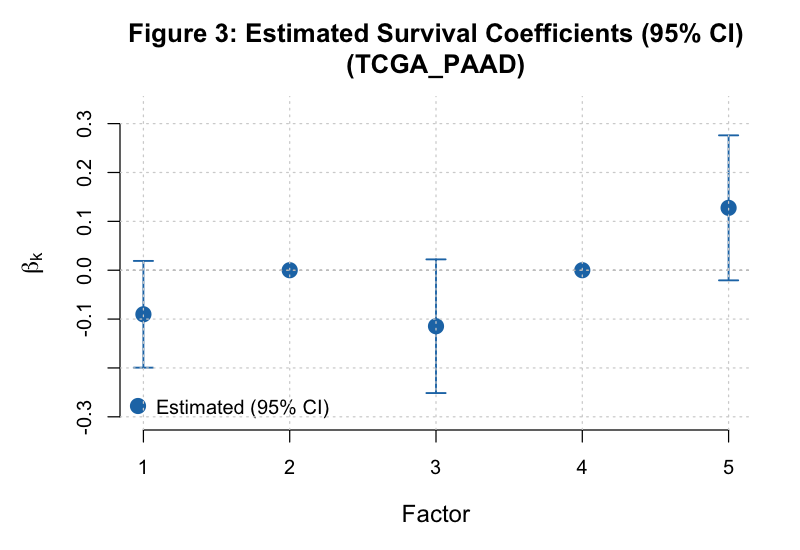

Survival coefficients $\hat{\beta}$ per GEP

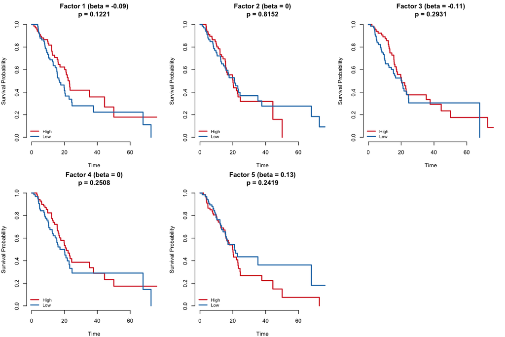

Kaplan-Meier survival curves by GEP activation

## Hold-Out Prediction

### Generalisation to Unseen Patients

| Dataset | C (PCA) | Best Condition | K | C (SBMF) | ΔC |
| --- | --- | --- | --- | --- | --- |
| CPTAC | 0.703 | PN K_eff | 8 | 0.635 | -0.068 |
| Dijk | 0.610 | PN K_eff | 10 | 0.544 | -0.066 |
| Moffitt | 0.571 | PL K=5 | 5 | 0.580 | 0.009 |
| PACA_AU array | 0.653 | PN K_eff | 8 | 0.738 | 0.085 |
| PACA_AU seq | 0.776 | PL K=5 | 5 | 0.889 | 0.113 |
| Puleo | 0.664 | PN K_eff | 10 | 0.674 | 0.010 |
| TCGA | 0.640 | PL K=5 | 5 | 0.707 | 0.067 |

- SBMF **beats PCA baseline on held-out patients in 5/7** cohorts
- Improvements most reliable when test set is large enough ($n_\text{test} \geq 20$)
- **Caveat:** small test sets ($n \leq 15$) produce noisy C-index estimates

## Future Directions & Summary

### Next Steps

1. **Gene set enrichment** — fgsea / Enrichr on top-loaded genes per GEP (MSigDB, KEGG, Reactome)
2. **CV-based K selection** — cross-validated C-index on Longleaf HPC ($K_\text{max} \geq 15$)
3. **Multi-dataset shared factors** — identify GEPs replicating across cohorts
4. **Full ELBO as model selection** — compare models by variational lower bound
5. **Manuscript preparation**

## Discussion

**Questions, suggestions, and feedback welcome!**

Andrew Walther · awalther@unc.edu

Department of Biostatistics, UNC Gillings School of Global Public Health

## Pooled RNA-seq Analysis

### Cross-Cohort Validation: TCGA + Dijk + PACA_AU_seq

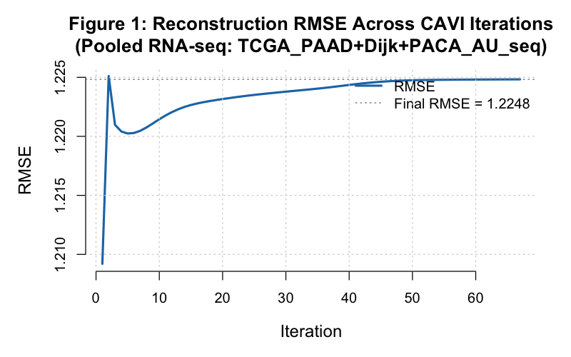

RMSE convergence — pooled RNA-seq ($n = 286$)

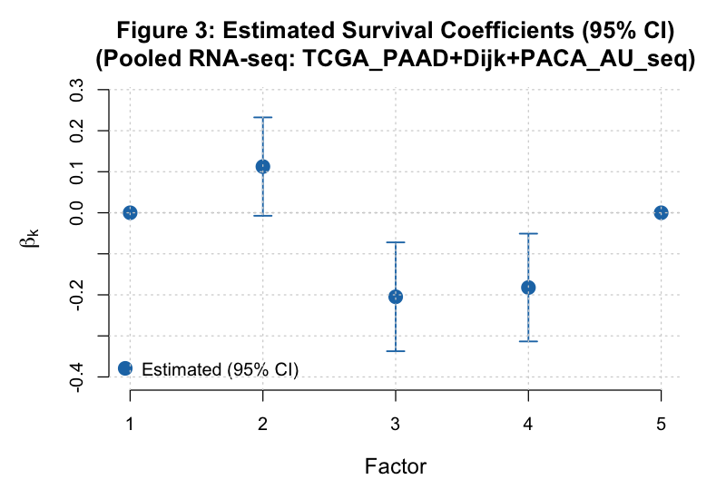

Survival coefficients $\hat{\beta}$ — pooled

- **Pooled:** $n = 286$ patients, 1,573 common genes (intersection across 3 RNA-seq cohorts)
- Converges in 67 iterations
- Tests whether gene programs replicate when patients from different studies are combined

## EBNM Deep Dive

### Empirical Bayes Normal Means — Full Detail

Each CAVI update reduces to an EBNM sub-problem:

**Normal-means form**

- Observed pseudo-data = signal + noise
- Pseudo-data term: `x_j = B_j / A_j`
- Scale term: `s_j = A_j^{-1/2}`
- Noise model: `epsilon_j ~ Normal(0, s_j^2)`

**What EBNM estimates**

- Learns the prior `g` by maximizing the marginal likelihood over candidate priors
- Returns a posterior mean for each coordinate
- Returns a posterior variance for each coordinate
- Critical second moment = variance + mean squared

This prevents overfitting to uncertain parameter estimates and gives the error-in-variables correction used in the SBMF updates.

## GEP Heatmap: Puleo Array

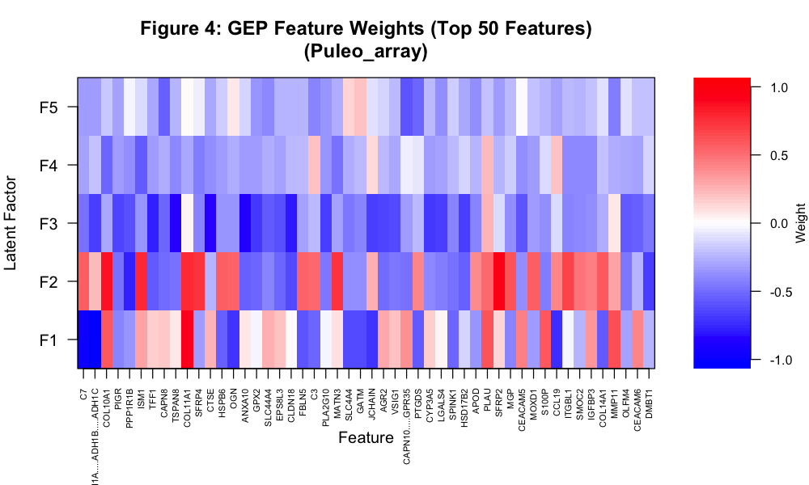

## ELBO Convergence Traces

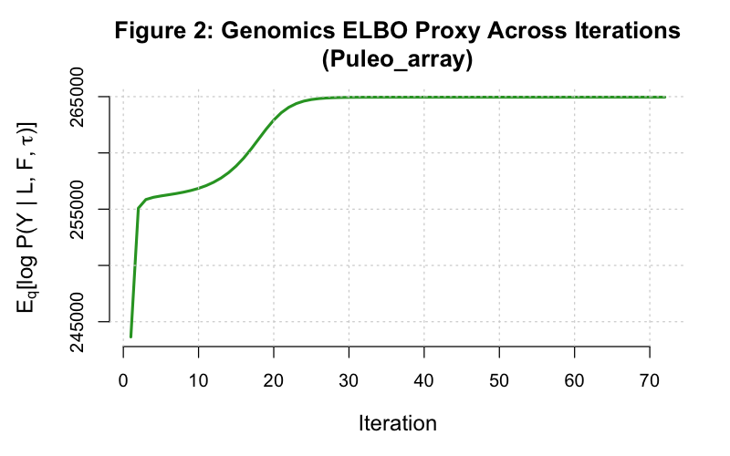

ELBO trace — Puleo array

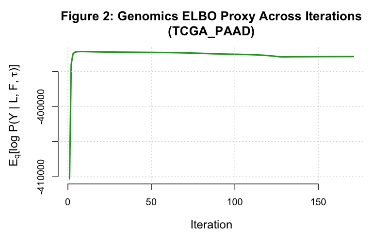

ELBO trace — TCGA_PAAD

## Tau/Precision Distribution

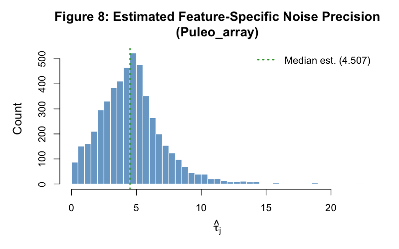

Gene-specific precision $\hat{\tau}_j$ — Puleo array

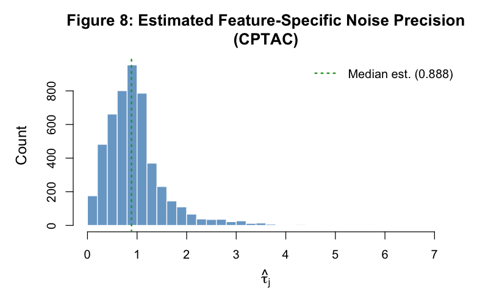

Gene-specific precision $\hat{\tau}_j$ — CPTAC

Heteroscedastic noise model: each gene has its own precision estimate. Some genes are precisely measured (high $\tau$), others are noisy (low $\tau$).

## Per-Cohort Beta Comparisons

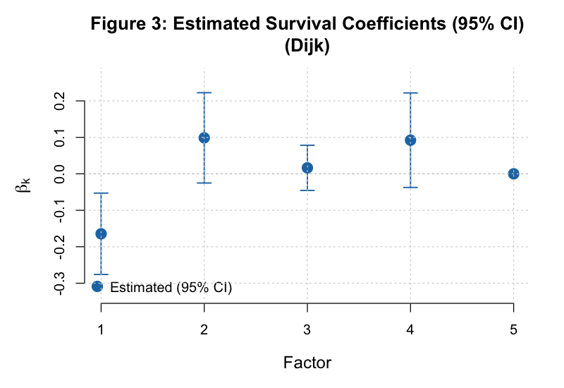

Dijk

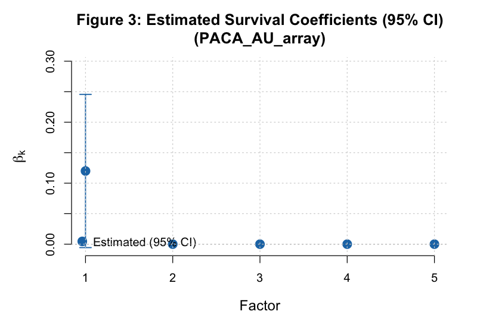

PACA_AU_array

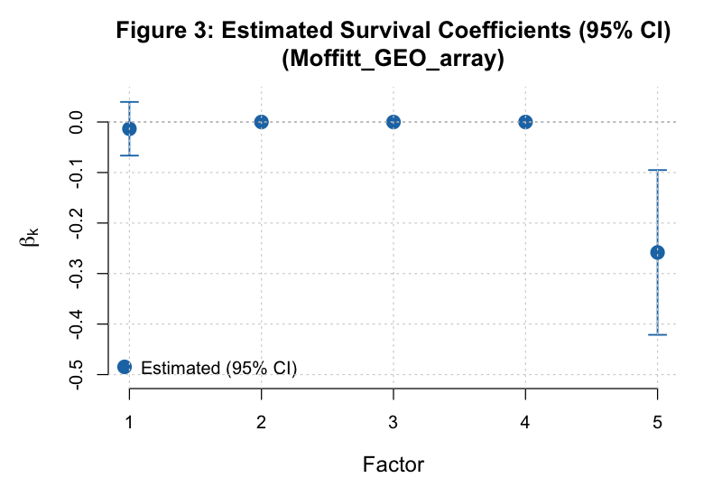

Moffitt

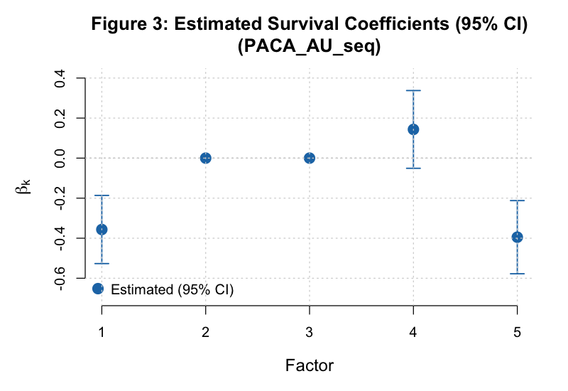

PACA_AU_seq

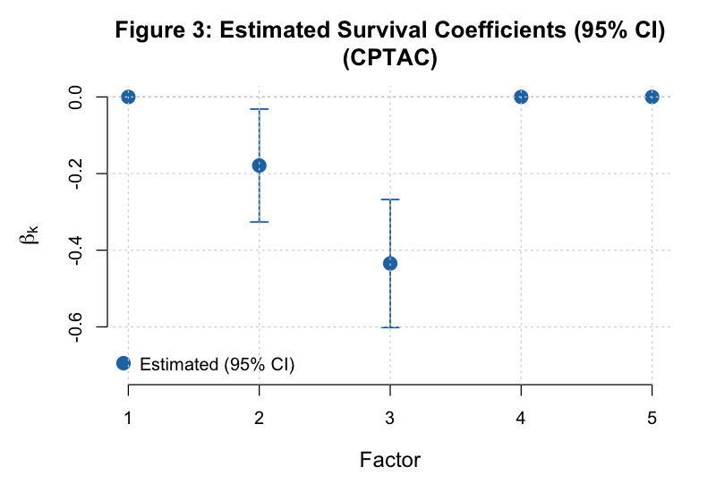

CPTAC

## Per-Cohort Kaplan-Meier Curves

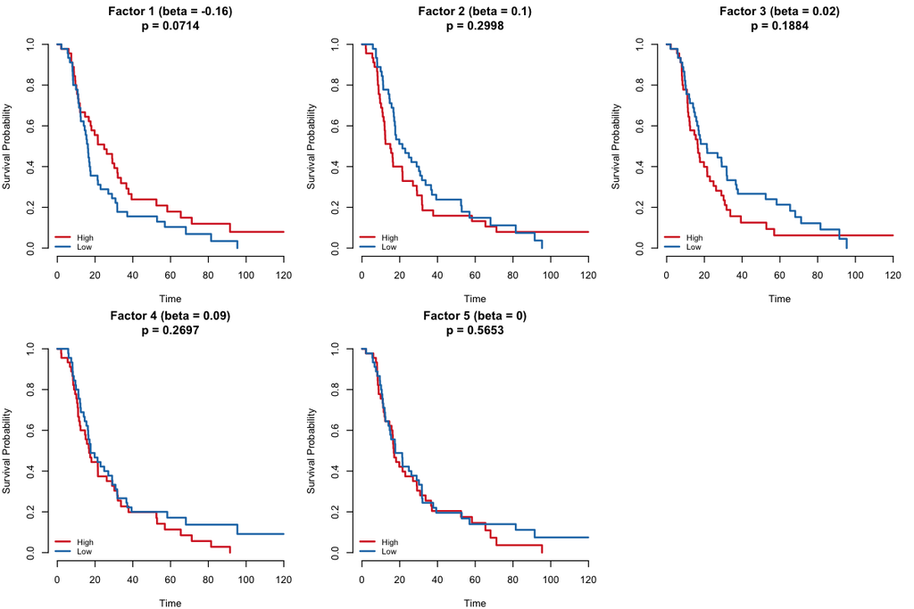

Dijk

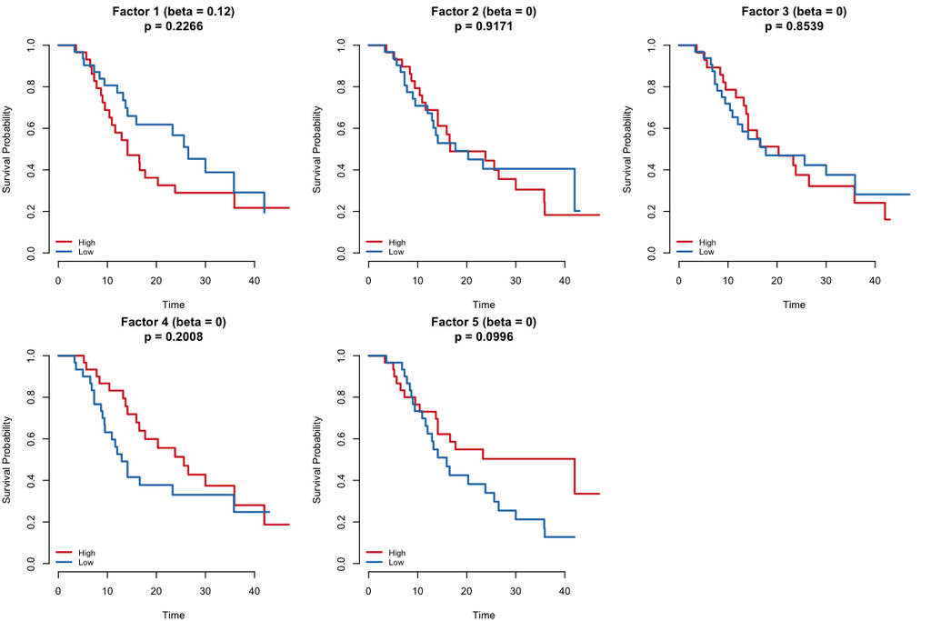

PACA_AU_array

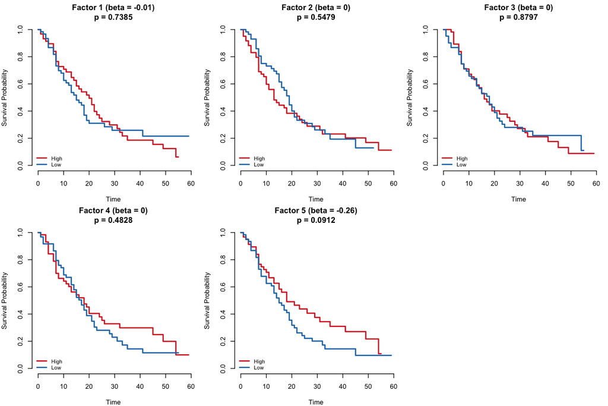

Moffitt

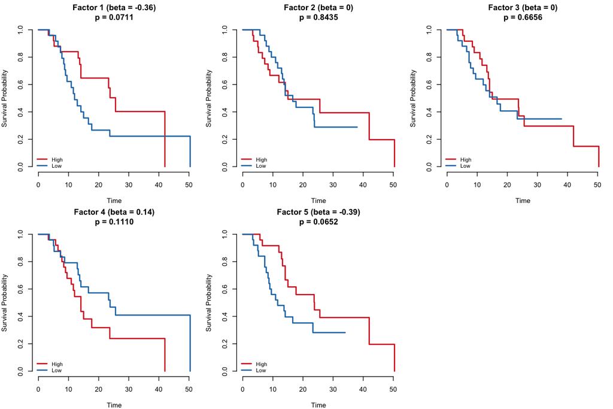

PACA_AU_seq

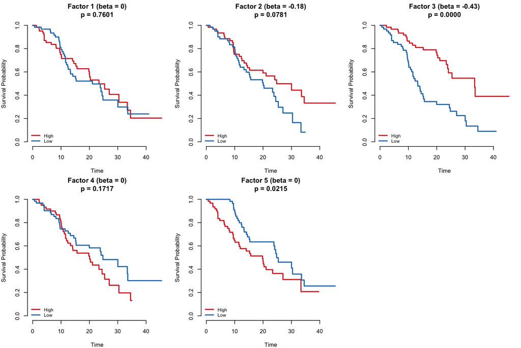

CPTAC

## Signal Recovery: Synthetic Detail

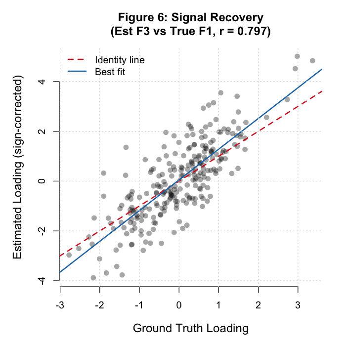

Detailed signal recovery — true vs. estimated factor structure

## Method Comparison

### SBMF vs. Penalised Supervised MF Approaches

| Feature | Penalised MF (e.g., deSurv) | SBMF (this work) |
| --- | --- | --- |
| **Inference** | Penalised optimisation | Full Bayesian (CAVI) |
| **Objective balance** | Tuning parameter alpha | ELBO — natural balance |
| **Priors** | Fixed penalty lambda | EBNM — prior learns from data |
| **Uncertainty** | Point estimates only | Posterior mean + variance |
| **K selection** | CV grid search | Auto-prune ($K_\text{eff}$) |
| **Constraints** | Nonnegative (NMF) | Unconstrained (allows negative loadings) |
| **Error-in-variables** | Not addressed | Uses Var($L$) + E($L$)$^2$ correction |
| **Second moments** | N/A | Prevents overfitting to uncertain loadings |

[figure not shown]

Rashid Lab · UNC Chapel Hill